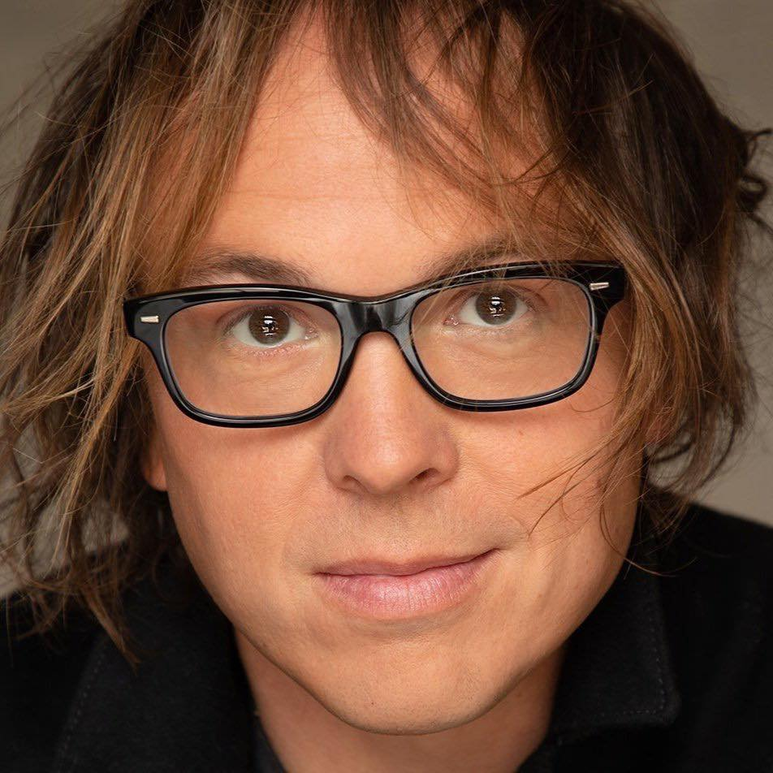

# Ricky Woznichak

Master’s of Science Digital Marketing

[Github](https://github.com/R4Dummies) [LinkedIn](https://www.linkedin.com/in/rickywoznichak/)

# Hello…

I’m Ricky Woznichak, a passionate digital marketing professional and current M.S. candidate in Digital Marketing at Cal Poly Pomona. Prior to my stint as an actor, I cut my teeth as an Assistant Digital Media Planner at UM, crafting campaigns for clients like Sony Home Entertainment and IHOP. Along the way I also honed my storytelling and people skills as a substitute teacher and—true story—an awesome waiter. I’ve led SEO initiatives, mastered tools like Google Analytics and SEMrush, and built interactive R and Quarto dashboards that turn complex insights into clear action. When I’m not geeking out over forecasting models for my Productfolio.com thesis, you’ll find me strolling with my dog Jimmy — because great ideas often strike when you’re off screen.

You can find my entire journey on Linkedin - Let’s Connect!

## Education

### Bachelor’s of Science in Marketing Management

- California State Polytechnic University, Pomona | California | June 2010

### Master’s of Science in Digital Marketing

- California State Polytechnic University, Pomona | California | August 2025

## Work Experience

John Franklin Insurance | Marketing Manager | 2024-2025

Los Angeles Unified School District |Substitute Teacher & Special Education Teacher | 2019—2024

Mama Shelter, Esterel, Mixto | Server + Banquet Server |2013—2024

Studio71 | Sales Development Coordinator | 2012—2013

Universal McCann | Assistant Digital Media Planner |2011—2012

Universal Music Group | Digital Marketing Coordinator | 2010—2011